# Group Project 2: CSIT-165 COVID-19 Global & US Analysis

Riley Williams (WHO) & Stirling Schabacker (USPRT)

2026-05-18

# Data

### GitHub Repository Link

https://github.com/stirling834-ops/CSIT-165/tree/8d005d09f497ba336e7788c7bf476e741492f32d/Project-2

## WHO: Global Data (Riley)

```r
confirmed_global <- read_csv("https://raw.githubusercontent.com/CSSEGISandData/COVID-19/master/csse_covid_19_data/csse_covid_19_time_series/time_series_covid19_confirmed_global.csv")

deaths_global <- read_csv("https://raw.githubusercontent.com/CSSEGISandData/COVID-19/master/csse_covid_19_data/csse_covid_19_time_series/time_series_covid19_deaths_global.csv")

recoveries_global <- download.file("https://raw.githubusercontent.com/CSSEGISandData/COVID-19/master/csse_covid_19_data/csse_covid_19_time_series/time_series_covid19_recovered_global.csv", destfile = "recoveries_global.csv")

confirmations_global <- confirmed_global
```

## USPRT: US Data (Stirling)

```r
confirmed_us <- read_csv("https://raw.githubusercontent.com/CSSEGISandData/COVID-19/master/csse_covid_19_data/csse_covid_19_time_series/time_series_covid19_confirmed_US.csv")

deaths_us <- read_csv("https://raw.githubusercontent.com/CSSEGISandData/COVID-19/master/csse_covid_19_data/csse_covid_19_time_series/time_series_covid19_deaths_US.csv")
```

# Objective 1 - Global Map

```r
# Step 1: Create dataframes for datapoints on the plot
# Creating a vector with all unique regions in the dataset
unique_regions <- unique(confirmations_global$`Country/Region`)
# Creating a dataframe containing the sums of every data for every unique country
confirmations_sums <- data.frame(matrix(nrow = length(unique_regions), ncol = 4))
colnames(confirmations_sums) <- c(colnames(confirmations_global[2:4]), colnames(confirmations_global[length(confirmations_global[1,])]))

# Using dplyr to put the needed sum of all of the values for every date according to each unique country for both
# confirmations & deaths on the global scale

# Confirmation Sums
confirmations_sums <- confirmations_global %>%
  group_by(`Country/Region`) %>%
  summarise(
    across(2:3, mean),
    across(ncol(confirmations_global)-1, sum)
  )
# Deaths Sums
deaths_sums <- deaths_global %>%
  group_by(`Country/Region`) %>%
  summarise(
    across(2:3, mean),
    across(ncol(deaths_global)-1, sum)
  )

# Step 2: Creating a global map plot with leaflet
# Define quartile breakpoints for color scaling
conf_breaks <- quantile(confirmations_sums [[4]], probs = c(0, 0.25, 0.75, 1), na.rm = TRUE)
death_breaks <- quantile(deaths_sums[[4]], probs = c(0, 0.25, 0.75, 1), na.rm = TRUE)

pal1 <- colorBin(c("blue", "orange", "red"), domain = confirmations_sums[[4]], bins = conf_breaks)
pal2 <- colorBin(c("blue", "orange", "red"), domain = deaths_sums[[4]], bins = death_breaks)

leaflet(data = confirmations_sums) %>%
  addProviderTiles("CartoDB.Positron") %>%
  setView(lng = 0, lat = 0, zoom = 2) %>%
  addCircles(
    lat = ~Lat,
    lng = ~Long,
    label = ~`Country/Region`,
    color = ~pal1(confirmations_sums[[4]]),
    popup = ~paste("Confirmations:", confirmations_sums[[4]]),
    radius = 75000,
    group = "Confirmations"
  ) %>%
  addCircles(
    lat = ~Lat,
    lng = ~Long,
    label = ~`Country/Region`,
    color = ~pal2(deaths_sums[[4]]),
    popup = ~paste("Deaths:", deaths_sums[[4]]),
    radius = 75000,
    group = "Deaths"
  ) %>%
  addLayersControl(
    overlayGroups = c("Confirmations", "Deaths"),
    options = layersControlOptions(collapsed = FALSE)
  ) %>%
  hideGroup("Deaths")
```

[interactive chart not shown]

### Write Up

#### WHO:

In this global map, the areas with data on COVID-19 confirmations and deaths are shown. The data points are colored depending on the intensity of confirmations/deaths. In this case, blue represents a low amount, orange to it represent a middling amount, and red represents a high amount. The intensities between confirmations and deaths line up, with every data point between both representing the same country having similar intensities. There are notable areas with higher intensities, such as the Americas, throughout Europe, South Africa, India and areas around, Australia, Indonesia, and the Philippines.

#### USPRT:

The map reveals that Europe and the United States were hit hardest in terms of both confirmations and deaths, though for different reasons. Europe’s high density of neighboring countries likely increased communicability across borders, while the US’s sheer geographic size and population drove its raw numbers. Summing by country rather than province makes the map significantly more readable; individual province-level dots would create visual noise that obscures the broader geographic patterns important for public health messaging, even if some regional variation is lost in the aggregation. Countries with high confirmation counts generally also showed high death counts, though the relationship was not 1:1, which likely reflects differences in healthcare access, reporting standards, and policy responses across countries (and raises interesting questions about whether some COVID deaths may have been recorded under other causes in certain regions).

# Objective 2 - Narrowing Down Hot Spots

```r
# Rearranging both confirmation_sums & deaths_sums to be in descending order based on values for confirmations & deaths
# Confirmations
confirmations_sums <- confirmations_sums %>%
  arrange(desc(confirmations_sums[[4]]))
# Deaths
deaths_sums <- deaths_sums %>%
  arrange(desc(deaths_sums[[4]]))
# Creating a dataframe meant for the table to use. This includes a
tally_table <- data.frame(
  Rank = 1:nrow(confirmations_sums),
  Country1 = confirmations_sums$`Country/Region`,
  Count1 = confirmations_sums[[4]],
  Country2 = deaths_sums$`Country/Region`,
  Count2 = deaths_sums[[4]]
)
# Now to create the table itself with the kable package
kable(
  head(tally_table, 50),
  col.names = c("Rank", "Country", "Count", "Country", "Count"),
  format = "html"
) %>%
  kable_styling(bootstrap_options = c("striped", "hover"), full_width = FALSE) %>%
  add_header_above(c(
    " " = 1,
    "Confirmations" = 2,
    "Deaths" = 2
  )) %>%
  column_spec(4, border_left = TRUE)
```

| Rank | Confirmations Country | Confirmations Count | Deaths Country | Deaths Count |
| --- | --- | --- | --- | --- |
| 1 | US | 103802702 | US | 1123836 |
| 2 | India | 44690738 | Brazil | 699276 |
| 3 | France | 39866718 | India | 530779 |
| 4 | Germany | 38249060 | Russia | 388478 |
| 5 | Brazil | 37076053 | Mexico | 333188 |
| 6 | Japan | 33320438 | United Kingdom | 220721 |
| 7 | Korea, South | 30615522 | Peru | 219539 |
| 8 | Italy | 25603510 | Italy | 188322 |
| 9 | United Kingdom | 24658705 | Germany | 168935 |
| 10 | Russia | 22075858 | France | 166176 |
| 11 | Turkey | 17042722 | Indonesia | 160941 |
| 12 | Spain | 13770429 | Iran | 144933 |
| 13 | Vietnam | 11526994 | Colombia | 142339 |
| 14 | Australia | 11399460 | Argentina | 130472 |
| 15 | Argentina | 10044957 | Spain | 119479 |
| 16 | Taiwan* | 9970937 | Ukraine | 119283 |
| 17 | Netherlands | 8712835 | Poland | 119010 |
| 18 | Iran | 7572311 | South Africa | 102595 |
| 19 | Mexico | 7483444 | Turkey | 101492 |
| 20 | Indonesia | 6738225 | China | 101056 |
| 21 | Poland | 6444960 | Japan | 72997 |
| 22 | Colombia | 6359093 | Romania | 67736 |
| 23 | Austria | 5961143 | Philippines | 66188 |
| 24 | Ukraine | 5711929 | Chile | 64273 |
| 25 | Portugal | 5570473 | Canada | 51720 |
| 26 | Greece | 5548487 | Hungary | 48762 |
| 27 | Chile | 5192286 | Vietnam | 43186 |
| 28 | Malaysia | 5044718 | Czechia | 42491 |
| 29 | China | 4903524 | Bulgaria | 38228 |
| 30 | Israel | 4803824 | Malaysia | 36967 |
| 31 | Belgium | 4739365 | Ecuador | 36014 |
| 32 | Thailand | 4728182 | Greece | 34779 |
| 33 | Czechia | 4618256 | Korea, South | 34093 |
| 34 | Canada | 4617095 | Thailand | 33918 |
| 35 | Peru | 4487553 | Belgium | 33814 |
| 36 | Switzerland | 4413911 | Pakistan | 30644 |
| 37 | Philippines | 4077452 | Bangladesh | 29445 |
| 38 | South Africa | 4067067 | Tunisia | 29341 |
| 39 | Denmark | 3451036 | Portugal | 26266 |
| 40 | Romania | 3346046 | Iraq | 25375 |
| 41 | Sweden | 2699339 | Egypt | 24812 |
| 42 | Slovakia | 2667551 | Sweden | 23777 |
| 43 | Serbia | 2500142 | Netherlands | 23705 |
| 44 | Iraq | 2465545 | Bolivia | 22365 |
| 45 | New Zealand | 2236114 | Austria | 21970 |
| 46 | Singapore | 2235294 | Slovakia | 21035 |
| 47 | Hungary | 2196804 | Guatemala | 20182 |
| 48 | Bangladesh | 2037871 | Paraguay | 19878 |
| 49 | Georgia | 1827537 | Australia | 19574 |
| 50 | Jordan | 1746997 | Burma | 19490 |

### Write Up

#### WHO:

Generally the same countries have high rankings between both confirmations and deaths, though countries such as the United States, India, and Brazil have the highest confirmations and deaths. Countries such as Mexico and Peru have a noticeably large amount of deaths, ranking higher than in confirmations. The United States notably has the highest confirmations and deaths by a notably large margin. Generally though, it seems that the countries with higher populations have the most amount of confirmations and deaths as shown in the table.

#### USPRT:

The United States leads in both confirmations and deaths, which is unsurprising given its combination of dense urban population clusters, a largely privatized healthcare system, and limited social safety net programs that would have made sustained social distancing or reduced-exposure behaviors difficult for many workers. The rankings for confirmations and deaths are not identical. Some countries appear higher in one list than the other, which may reflect differences in how COVID deaths were reported and classified, particularly in cases where preexisting conditions like heart disease complicated cause-of-death determinations. Countries that rank disproportionately high in deaths relative to their confirmation count likely faced compounding challenges including limited healthcare infrastructure, inconsistent public health messaging, weaker mask and social distancing mandates, and lower vaccination rates, which would increase the likelihood that a confirmed case resulted in death.

# Objective 3 - Zooming Into Our State

```r
ca_confirmed <- confirmed_us %>%
  filter(Province_State == "California") %>%
  select(Admin2, starts_with("1/"), starts_with("2/"), starts_with("3/"),
         starts_with("4/"), starts_with("5/"), starts_with("6/"),
         starts_with("7/"), starts_with("8/"), starts_with("9/"),
         starts_with("10/"), starts_with("11/"), starts_with("12/")) %>%
  pivot_longer(-Admin2, names_to = "date", values_to = "confirmed") %>%
  mutate(date = as.Date(date, format = "%m/%d/%y"))
```

```r
ca_total <- ca_confirmed %>%
  group_by(date) %>%
  summarise(confirmed = sum(confirmed))
```

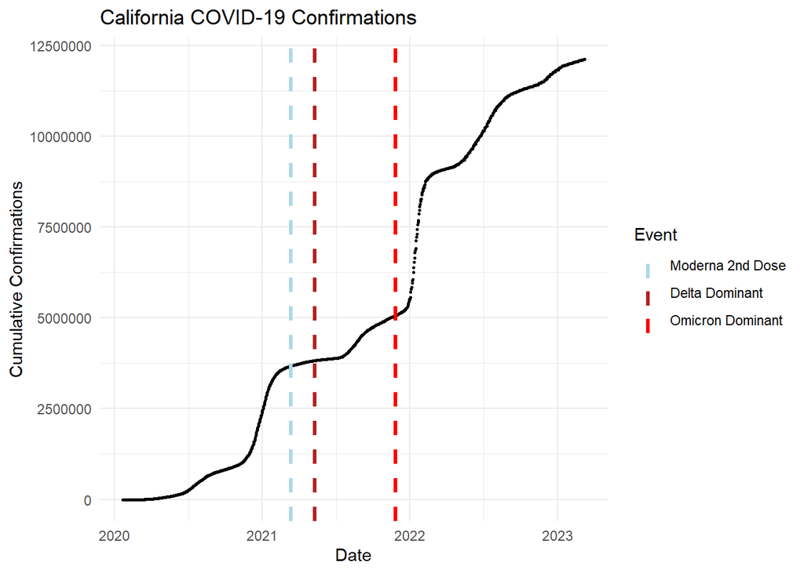

```r
moderna_date <- as.Date("2021-01-29") + weeks(6)
delta_date <- as.Date("2021-05-11")
omicron_date <- as.Date("2021-11-26")

ca_plot <- ggplot(ca_total, aes(x = date, y = confirmed)) +
  geom_point(size = 0.5) +
  geom_vline(aes(xintercept = moderna_date, color = "Moderna 2nd Dose"), linetype = "dashed", linewidth = 1.2) +
  geom_vline(aes(xintercept = delta_date, color = "Delta Dominant"), linetype = "dashed", linewidth = 1.2) +
  geom_vline(aes(xintercept = omicron_date, color = "Omicron Dominant"), linetype = "dashed", linewidth = 1.2) +
  scale_color_manual(values = c("Moderna 2nd Dose" = "lightblue", "Delta Dominant" = "firebrick", "Omicron Dominant" = "red"),
                   breaks = c("Moderna 2nd Dose", "Delta Dominant", "Omicron Dominant")) +

  labs(title = "California COVID-19 Confirmations",
       x = "Date", y = "Cumulative Confirmations", color = "Event") +
  theme_minimal()

ca_plot
```

```r
top3_cities <- ca_confirmed %>%
  filter(Admin2 %in% c("Los Angeles", "San Diego", "Orange"))
```

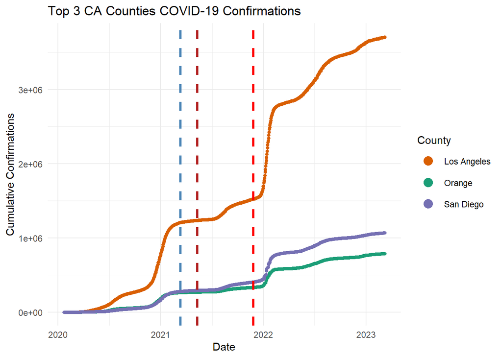

```r
city_plot <- ggplot(top3_cities, aes(x = date, y = confirmed, color = Admin2)) +
  geom_point(size = 1.2) +
  geom_vline(xintercept = moderna_date, color = "steelblue", linetype = "dashed", linewidth = 1.2) +
  geom_vline(xintercept = delta_date, color = "firebrick", linetype = "dashed", linewidth = 1.2) +
  geom_vline(xintercept = omicron_date, color = "red", linetype = "dashed", linewidth = 1.2) +
  scale_color_manual(values = c("Los Angeles" = "#d95f02", "Orange" = "#1b9e77", "San Diego" = "#7570b3")) +
  labs(title = "Top 3 CA Counties COVID-19 Confirmations",
       x = "Date", y = "Cumulative Confirmations", color = "County") +
  theme_minimal() +
  theme(legend.key.size = unit(1.5, "lines")) +
  guides(color = guide_legend(override.aes = list(size = 4)))

city_plot
```

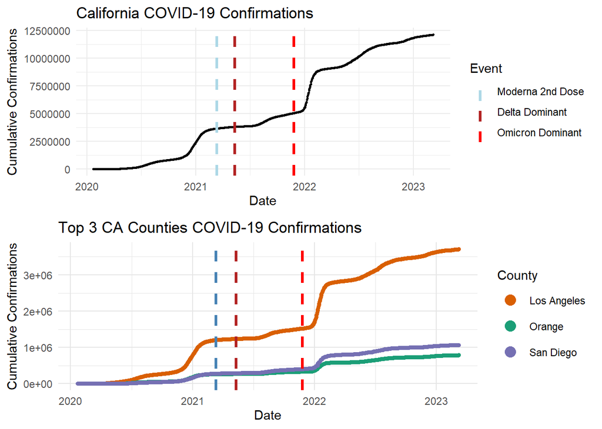

```r
city_plot <- city_plot + theme(panel.grid = element_line(color = "grey90"))
plot_grid(ca_plot, city_plot, ncol = 1)
```

### Write Up

#### WHO:

The trajectory of the COVID-19 cases in California alone is rather telling, given that the state’s total confirmations (12129699 cases) as of March 9th, 2023 makes up roughly 12% of the total amount of cases for the United States (103802702 cases). The rate of infection does notably speed up and slow down at different time periods, with the more notable high rates being around the start of 2021 before the second Moderna dose, the start of 2022 after the Omicron variant becomes the dominant COVID-19 strain, and around the middle of 2022. Zooming into specific cities such as Los Angeles, Orange County, and San Diego, they exhibit identical trends to the trend for California showing the rate of infection increasing and decreasing at around the same times, though on different scales. Los Angeles notably has far more cases than Orange County and San Diego, though this can be explained by its large, dense population. Given that the trends for each city are identical to California’s (though scaling differs), it may be reflective of COVID-19’s impact on the world.

#### USPRT:

California’s COVID-19 confirmation trajectory shows steady cumulative growth throughout the pandemic, with the curve never meaningfully declining. Even the smaller fluctuations visible in the data represent slowdowns in the rate of new cases rather than any true reduction in total confirmations. The Moderna second dose appears to have had some moderating effect, as the period following the blue line shows a relative plateau before delta became dominant; however, when omnicron emerged as the dominate strain, it is clear that the vaccine’s efficacy against new variants had reached its limits, with a spike steeper than the initial pandemic growth rate (which was likely compounded by increased public complacency around preventative measures given widespread vaccination). Los Angeles, Orange, and San Diego counties all follow the same general trajectory, suggesting that the shape of the curve is driven more by statewide conditions than local factors; however, LA’s dramatically higher counts reflect both its larger population and the unavoidable density of contact in a metro area that size, with its fluctuations proportionally mirroring those of the smaller counties

# Objective 4 - Digging Deeper

```r
last_col_confirmed <- ncol(confirmed_us)
last_col_deaths <- ncol(deaths_us)

obj4_data <- deaths_us %>%
  select(Admin2, Province_State, Population) %>%
  mutate(
    confirmed = confirmed_us[[last_col_confirmed]],
    deaths = deaths_us[[last_col_deaths]]
  ) %>%
  filter(Population > 0, confirmed > 0, deaths > 0)
```

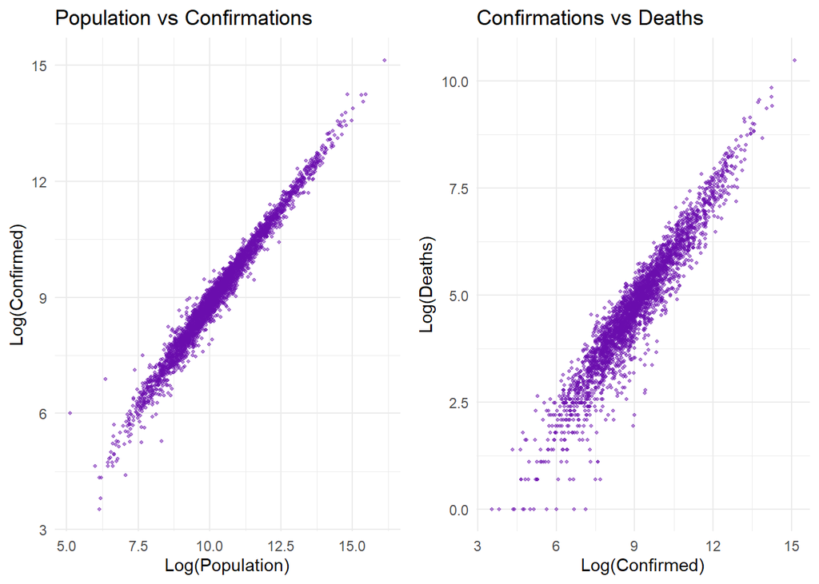

```r
pop_plot <- ggplot(obj4_data, aes(x = log(Population), y = log(confirmed))) +
  geom_point(size = 0.8, alpha = 0.5, color = "#6a0dad") +
  labs(title = "Population vs Confirmations",
       x = "Log(Population)", y = "Log(Confirmed)") +
  theme_minimal()

death_plot <- ggplot(obj4_data, aes(x = log(confirmed), y = log(deaths))) +
  geom_point(size = 0.8, alpha = 0.5, color = "#6a0dad") +
  labs(title = "Confirmations vs Deaths",
       x = "Log(Confirmed)", y = "Log(Deaths)") +
  theme_minimal()

plot_grid(pop_plot, death_plot, ncol = 2)
```

### Write Up

#### WHO:

Upon further analysis of the number of the population of the United States, the number of COVID-19 confirmations, and the number of deaths due to COVID-19, it has been found that by doing comparisons of them, relationships can be found. Firstly, it has been found that taking logarithms of populations and confirmations and comparing them against each other, a positive linear trend is found, indicating a positive relationship. It indicates that with a higher and denser population, there will be more COVID-19 confirmations. Furthermore, doing a logarithmic comparison of confirmations against deaths reveals a positive relationship, indicating that with more confirmations, there will be more deaths. This lines up in a general sense with the United States having the highest amount of confirmations and the highest amount of deaths, though there can be outliers due to outside factors. Brazil for example as shown in the table from Objective 2 has the second highest amount of deaths in the world, but ranks #5 in confirmations.

#### USPRT:

The log-transformed population vs. confirmations plot reveals a clear positive relationship between population size and case counts, though population alone does not tell the whole story. Factors like population density, socioeconomic status, and the necessity of in-person work would all compound the effect of raw population numbers on confirmation rates. The confirmations vs. deaths plot suggests the relationship is generally consistent but not without variation, which may reflect gaps in reporting on both ends. Some confirmations may have been missed in areas where people attributed symptoms to other illnesses, while some deaths may have been complicated by comorbidities or represent long-COVID outcomes. This raises the question of whether a death caused by long-COVID complications would be classified as a COVID death in the data. The log transformation was necessary to standardize the scale across counties with vastly different population sizes. Without it, the plot would be dominated by a few large counties like LA while smaller counties would be compressed into an unreadable cluster at the bottom, making any relationship between population and confirmations effectively invisible.

# Summary

#### WHO:

This analysis shows that with a virus such as COVID-19 rapidly mutating and with vaccines being distributed, the rate of infection can drastically change. At the same time, the trends of showing the rate of infection in California may be reflective of infection throughout the world. In a general sense, densely populated regions of the world have a higher amount of confirmations and deaths. However with countries such as Brazil having a noticeably high amount of deaths for its number of confirmations though, it teaches the important lesson that there can be other factors to consider when aiming to reduce the number of deaths in a future pandemic. This will be important for ensuring that the rate of infection for future viruses and deaths caused by it to be mitigated.

#### USPRT:

Globally, this analysis revealed a world learning in real time how to respond to a widespread pandemic, with meaningful variation in outcomes across countries that will be vital to future epidemiological research. Public health and reporting policies proved integral to the relationship between confirmations and deaths, as countries with stronger infrastructure and more consistent messaging generally fared better, while densely populated areas with limited social protections suffered disproportionately. California’s trajectory illustrates how even within a single state, population size and density drove case counts, and the emergence of new variants like delta and omicron demonstrated the limits of early vaccine efficacy against a rapidly mutating virus. The long-term effects of COVID on survivors, including long-COVID outcomes and their implications for mortality reporting, remain an open area of study, and standardizing both public health responses and data collection practices will be essential to reducing the initial loss of life in any future pandemic.